# PlacidiDiscreteLik

Leonardo Placidi

18/9/2020

# Extra For Project: Discrete Likelihood

## Here i load libraries and download the data, creatin a dat.jagRealData to be used when the models will be ready.

```r
set.seed(123)
require(tidyverse)
```

```r
require(ggplot2)
require(VGAM)
require(R2jags)
require(mcmcse)
require(bayesplot)
require(TeachingDemos)
require(nimble)
require(sadists)
require(EnvStats)
require(sadists)
require(stats)
require(rmutil)
set.seed(123)
LeagueData <- read.csv("ProjectFinaldataLeagueofLegends.csv")
#Let's first drop the column X since we already have automatic indexes
LeagueData = subset(LeagueData, select = -c(X) )
head(LeagueData)
```

```
##   tier     summonerName leaguePoints wins losses veteran
## 1 GOLD           T0kki3           52  183    169    True
## 2 GOLD    CrimsÃ\230nBlade            0   52     49   False
## 3 GOLD     I LIKE FLIES          100   56     56   False
## 4 GOLD     DaKin Kowine            2  197    191   False
## 5 GOLD AnatolÃ®an eagle            0    2     10   False
## 6 GOLD     TOXIC I Himi           18  174    197   False
```

but they are too big to be used in jags, so i select a balanced subset of them:

```r
#Change every IRON ->1, BRONZE->2 etc
Changer <- function(LeagueData_tier){
ChangedTier <- c()
for(i in LeagueData_tier){
  if(i == 'IRON'){
    ChangedTier <- c(ChangedTier, 1)

  }
  else if(i == 'BRONZE') {
    ChangedTier <- c(ChangedTier, 2)
  }
  else if(i == 'SILVER'){
    ChangedTier <- c(ChangedTier, 3)
    }
  else if(i == 'GOLD'){
    ChangedTier <- c(ChangedTier, 4)
  }
  else if(i == 'PLATINUM'){
    ChangedTier <- c(ChangedTier, 5)
  }
  else if(i == 'DIAMOND'){
    ChangedTier <- c(ChangedTier, 6)
  }
}
return(ChangedTier)
}
```

Here I create the balanced subset of my data.

```r
#we have to take 1500 for every rank!
#so we make a copy of our dataset, and we drop lines!
COPY<-data.frame(LeagueData)
head(COPY)
```

```
##   tier     summonerName leaguePoints wins losses veteran
## 1 GOLD           T0kki3           52  183    169    True
## 2 GOLD    CrimsÃ\230nBlade            0   52     49   False
## 3 GOLD     I LIKE FLIES          100   56     56   False
## 4 GOLD     DaKin Kowine            2  197    191   False
## 5 GOLD AnatolÃ®an eagle            0    2     10   False
## 6 GOLD     TOXIC I Himi           18  174    197   False
```

```r
#Indexes <- c()
Iron <- which(COPY$tier == 'IRON')[1:1050]
Bronze <-which(COPY$tier == 'BRONZE')[1:1050]
Silver <-which(COPY$tier == 'SILVER')[1:1050]
Gold <-which(COPY$tier == 'GOLD')[1:1050]
Platinum <-which(COPY$tier == 'PLATINUM')[1:1050]
Diamond <- which(COPY$tier == 'DIAMOND')[1:1050]
Indexes<- c(Iron, Bronze, Silver, Gold, Platinum, Diamond)
head(COPY[Indexes,] ) #That's the subset
```

```
##       tier   summonerName leaguePoints wins losses veteran
## 19804 IRON        krstos1           75   60     79   False
## 19805 IRON       duktrill           31   14     25   False
## 19806 IRON jetz komme ich            7    7     46   False
## 19807 IRON sandrius922002           58    4     12   False
## 19808 IRON    DR procktor            6   18     31   False
## 19809 IRON       mamomo96           29    7     18   False
```

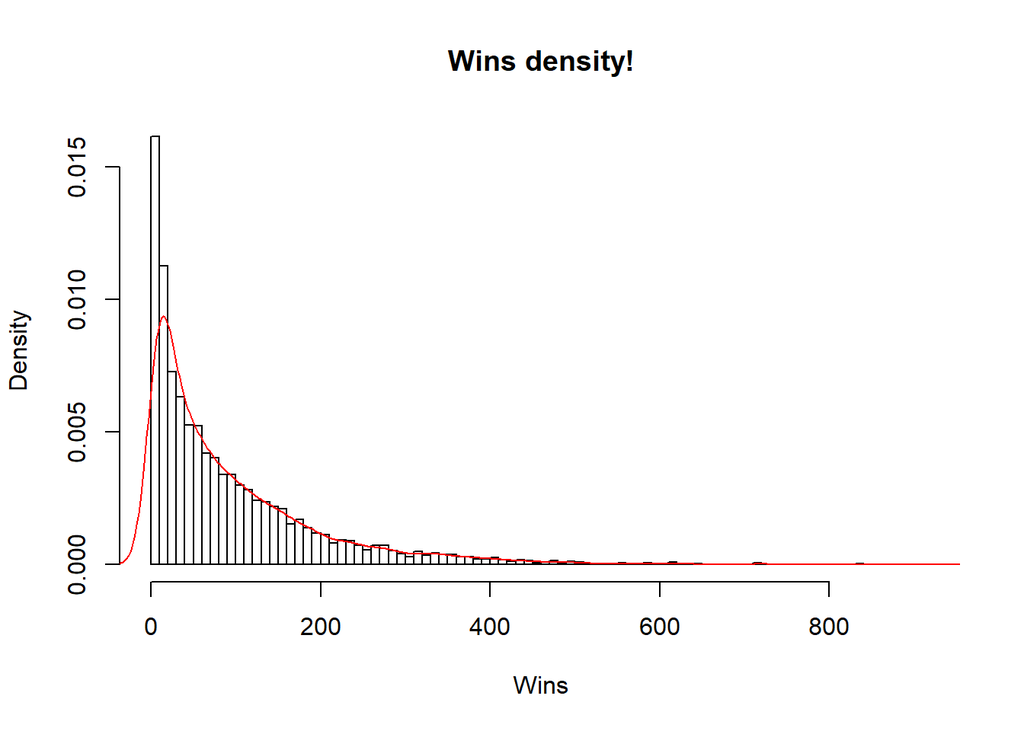

```r
COPY2 <- COPY[Indexes,]

#check the plot
hist(COPY2$wins,
     breaks = 100,
     prob = TRUE,
     main = "Wins density!",
     xlab = "Wins")

## Sample density
lines(density(COPY2$wins), col="red") #kinda perfectly as before ehehe
```

```r
tier2 <- Changer(COPY2$tier)
```

I observe that, compared to the full data this mantains the distribution, so there are no problems.

```r
set.seed(123)


Wins2 <- COPY2$wins
LP2 <- COPY2$leaguePoints
tier2 <- tier2
N2 <- length(Wins2)
tierstypes2 <- 6 #number of tiers

dat.jagRealData <- list(Wins = Wins2, LP = LP2, tier = tier2, N = N2, tierstypes = tierstypes2)
```

# Here I assume different likelihood, simulate from that likelihood and run the mcmc on the simulated data, to asses the quality of the model, later when I will have obtained my best with the simulated data, I will use the RealData in jags.

## Poisson Likelihood

```r
#So for now we have to simulate the losses, leaguePoints and wins.
set.seed(123)
#the league points are generally uniform values from 0 to 100 (we saw it before)

# leaguePoints
LP = sample(0:100, size = 1500, replace = TRUE )

#Now the tier that can be assumed uniform since we created ourselfes the dataset!!!!
# We would like tr <- c('IRON', 'BRONZE', 'SILVER', 'GOLD', 'PLATINUM', 'DIAMOND')
#but for semplicity we write, remembering that it will not matter the value for us
#just a programming ease
tr <- c(1,2,3,4,5,6)
tier = sample(tr, 1500, replace = TRUE)


#Parameters that influence the tier, in this case I saw empirically
#that the curve with lower tier coefficient
#resambles lower tiers, so this particular runif
a1tiers <- c()
for(i in 1:length(tr)){

    a1tiers <- c(a1tiers, runif(1,i/10, i/10 + 0.2)) #i/7

    }

#now I simulate the wins
Wins <- c()
base <- runif(1, 0.1, 0.7)
a1Lp <- runif(1, 0.01, 0.1)
for( i in 1:1500){

      #Here we notice that if the a1tiers increase, the distirbution is more likeli
      #from higher ranks(it increases the desnity of wins >0)
      #The LP is needed to scale a bit since if the player has many points
      #most likely has more wins
     h <- rpois(1, lambda =exp(base + a1tiers[tier[i]]+a1Lp*LP[i]))

     Wins = c(Wins, h)

}
length(Wins)
```

```
## [1] 1500
```

```r
print(a1tiers)
```

```
## [1] 0.1530799 0.3100384 0.3270489 0.5363644 0.5900702 0.6733289
```

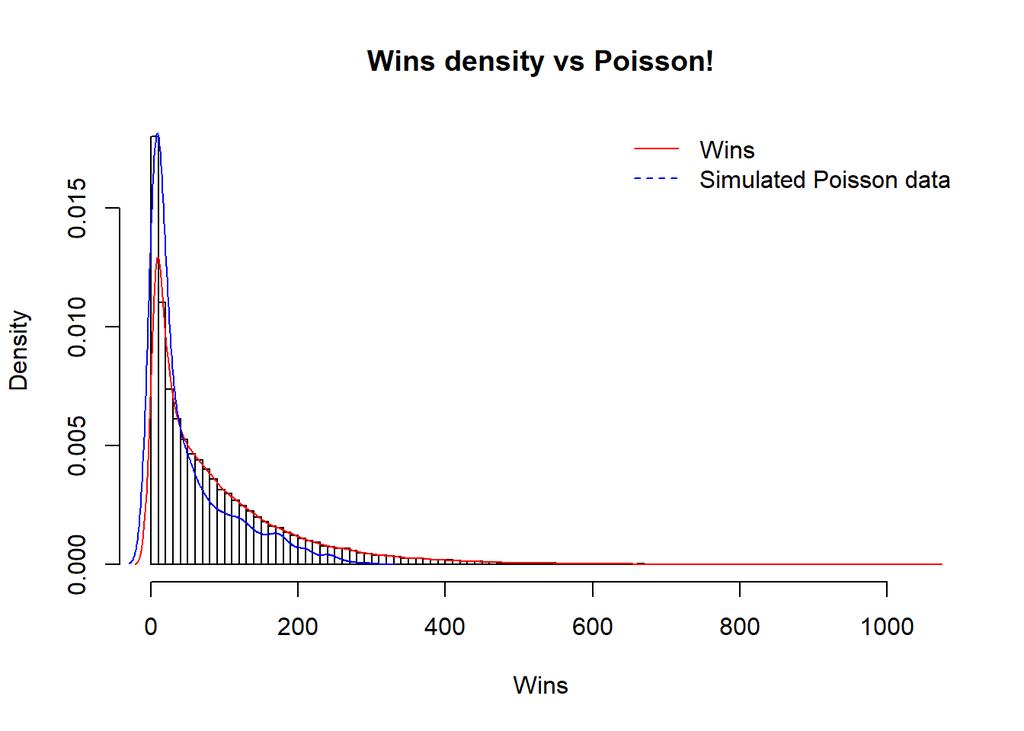

```r
#Let's visualize a little what we simulated in respected to the real data

hist(LeagueData$wins,
     breaks = 100,
     prob = TRUE,
     main = "Wins density vs Poisson!",
     xlab = "Wins")

## Sample density
lines(density(LeagueData$wins), col="red")

## Theoretical normal density
lines(density(Wins), col="Blue")

legend("topright", c("Wins", "Simulated Poisson data"),
       bty = "n", lty = c(1,2), col = c("red", "blue"))
```

```r
#I would say the plot (with only 1500 points) is not so bad!
```

```r
Wins2 <- Wins
LP2 <- LP
tier2 <- tier
#tr2 <- c('IRON', 'BRONZE', 'SILVER', 'GOLD', 'PLATINUM', 'DIAMOND')
N2 <- length(Wins)
tierstypes2 <- length(tr)

dat.jagsPoiss <- list(Wins = Wins2, LP = LP2, tier = tier2, N = N2, tierstypes = tierstypes2)
```

```r
set.seed(123)
#call it model5 since is the 5th of our project!

modelPois <- function() {
  # Likelihood
  for(i in 1:N)
  {
    #for now we just leave the rate parameters as in simulation as dependence
    Wins[i]  ~ dpois(a1[i])

    log(a1[i]) <-  base + a1tiers[tier[i]]+a1Lp*LP[i]

  }

  # Priors
  base ~ dunif(0.1, 0.8)
  a1Lp ~ dunif(0.01, 0.13)
  for (i in 1 : tierstypes)
  {
    a1tiers[i] ~ dunif(i/10, i/10 + 0.2) #as explained we want it to grow with the rank
  }

}



mod.paramsPois <- c( 'a1tiers', 'a1Lp', 'base')

mod1.fit <- jags(data = dat.jagsPoiss,                                    # DATA
                model.file = modelPois, #inits = mod.inits,          # MODEL
                parameters.to.save = mod.paramsPois,
                n.chains = 3, n.iter = 6000, n.burnin = 2000, n.thin=10)
```

```
## module glm loaded
```

```r
#Autocorrelation produces clumpy samples that are unrepresentative, in the short run, of the true underlying posterior distribution. Therefore, if #possible, we would like to get rid of autocorrelation so that the MCMC sample provides a more precise estimate of the posterior sample. One way #to decrease autocorrelation is to thin the sample, using only every nth step.


mod1.fit
```

```
## Inference for Bugs model at "C:/Users/leona/AppData/Local/Temp/RtmpIv49Px/model3c2063083eab.txt", fit using jags,
##  3 chains, each with 6000 iterations (first 2000 discarded), n.thin = 10
##  n.sims = 1200 iterations saved
##             mu.vect sd.vect     2.5%      25%      50%      75%    97.5%  Rhat
## a1Lp          0.046   0.000    0.046    0.046    0.046    0.046    0.046 1.013
## a1tiers[1]    0.189   0.030    0.132    0.167    0.191    0.212    0.241 1.005
## a1tiers[2]    0.327   0.030    0.268    0.305    0.329    0.350    0.379 1.008
## a1tiers[3]    0.350   0.027    0.303    0.328    0.351    0.372    0.399 1.006
## a1tiers[4]    0.555   0.028    0.501    0.534    0.557    0.578    0.598 1.004
## a1tiers[5]    0.616   0.029    0.560    0.594    0.617    0.639    0.667 1.004
## a1tiers[6]    0.683   0.029    0.627    0.661    0.685    0.706    0.733 1.005
## base          0.343   0.032    0.286    0.319    0.340    0.366    0.408 1.012
## deviance   8804.238   3.702 8798.917 8801.449 8803.666 8806.456 8812.402 1.009
##            n.eff
## a1Lp         170
## a1tiers[1]   400
## a1tiers[2]   300
## a1tiers[3]   330
## a1tiers[4]   480
## a1tiers[5]   520
## a1tiers[6]   430
## base         170
## deviance     370
##
## For each parameter, n.eff is a crude measure of effective sample size,
## and Rhat is the potential scale reduction factor (at convergence, Rhat=1).
##
## DIC info (using the rule, pD = var(deviance)/2)
## pD = 6.8 and DIC = 8811.1
## DIC is an estimate of expected predictive error (lower deviance is better).
```

```r
mod1.fit$BUGSoutput$summary
```

```
##                    mean           sd         2.5%          25%          50%
## a1Lp       4.596093e-02 0.0001915435 4.556651e-02 4.583334e-02 4.596269e-02
## a1tiers[1] 1.894013e-01 0.0297373173 1.323483e-01 1.672182e-01 1.911807e-01
## a1tiers[2] 3.269884e-01 0.0303854259 2.679673e-01 3.053805e-01 3.290422e-01
## a1tiers[3] 3.500370e-01 0.0274889054 3.028543e-01 3.277020e-01 3.514468e-01
## a1tiers[4] 5.546172e-01 0.0280424143 5.011198e-01 5.336615e-01 5.574434e-01
## a1tiers[5] 6.164397e-01 0.0290956711 5.602749e-01 5.943520e-01 6.172890e-01
## a1tiers[6] 6.832037e-01 0.0294861744 6.269298e-01 6.606674e-01 6.849412e-01
## base       3.425208e-01 0.0323699039 2.857780e-01 3.188434e-01 3.401972e-01
## deviance   8.804238e+03 3.7018155497 8.798917e+03 8.801449e+03 8.803666e+03
##                     75%        97.5%     Rhat n.eff
## a1Lp       4.609259e-02 4.633739e-02 1.013313   170
## a1tiers[1] 2.115621e-01 2.405440e-01 1.005393   400
## a1tiers[2] 3.504196e-01 3.787625e-01 1.008274   300
## a1tiers[3] 3.717565e-01 3.991599e-01 1.005910   330
## a1tiers[4] 5.775486e-01 5.981517e-01 1.004478   480
## a1tiers[5] 6.386043e-01 6.665220e-01 1.003589   520
## a1tiers[6] 7.055648e-01 7.335000e-01 1.004516   430
## base       3.655020e-01 4.079374e-01 1.011980   170
## deviance   8.806456e+03 8.812402e+03 1.009063   370
```

Even if this model performs well on the parameters the n.eff is very low and the iteration on the real data would be also worse, is not entirealy bad but we will see the NegBin will perform much better.

```r
print(a1Lp)
```

```
## [1] 0.04640241
```

```r
print(a1tiers)
```

```
## [1] 0.1530799 0.3100384 0.3270489 0.5363644 0.5900702 0.6733289
```

```r
print(base)
```

```
## [1] 0.3316788
```

Time to test it on the big data!

```r
mod1.fit <- jags(data = dat.jagRealData,                                    # DATA
                model.file = modelPois, #inits = mod.inits,          # MODEL
                parameters.to.save = mod.paramsPois,
                n.chains = 3, n.iter = 10000, n.burnin =
                  4000, n.thin=10)
#Autocorrelation produces clumpy samples that are unrepresentative, in the short run, of the true underlying posterior distribution. Therefore, if #possible, we would like to get rid of autocorrelation so that the MCMC sample provides a more precise estimate of the posterior sample. One way #to decrease autocorrelation is to thin the sample, using only every nth step.


mod1.fit
```

```
## Inference for Bugs model at "C:/Users/leona/AppData/Local/Temp/RtmpIv49Px/model3c20274679b.txt", fit using jags,
##  3 chains, each with 10000 iterations (first 4000 discarded), n.thin = 10
##  n.sims = 1800 iterations saved
##                mu.vect sd.vect        2.5%         25%         50%         75%
## a1Lp             0.042   0.000       0.041       0.042       0.042       0.042
## a1tiers[1]       0.168   0.006       0.156       0.164       0.168       0.172
## a1tiers[2]       0.200   0.000       0.200       0.200       0.200       0.200
## a1tiers[3]       0.500   0.000       0.500       0.500       0.500       0.500
## a1tiers[4]       0.600   0.000       0.600       0.600       0.600       0.600
## a1tiers[5]       0.700   0.000       0.700       0.700       0.700       0.700
## a1tiers[6]       0.800   0.000       0.800       0.800       0.800       0.800
## base             0.800   0.000       0.800       0.800       0.800       0.800
## deviance   2093644.533   5.151 2093636.340 2093640.728 2093643.928 2093647.625
##                  97.5%  Rhat n.eff
## a1Lp             0.042 1.000  1800
## a1tiers[1]       0.179 1.001  1800
## a1tiers[2]       0.200 1.003  1800
## a1tiers[3]       0.500 1.000     1
## a1tiers[4]       0.600 1.000     1
## a1tiers[5]       0.700 1.000     1
## a1tiers[6]       0.800 1.000     1
## base             0.800 1.000     1
## deviance   2093655.859 1.000     1
##
## For each parameter, n.eff is a crude measure of effective sample size,
## and Rhat is the potential scale reduction factor (at convergence, Rhat=1).
##
## DIC info (using the rule, pD = var(deviance)/2)
## pD = 13.3 and DIC = 2093657.8
## DIC is an estimate of expected predictive error (lower deviance is better).
```

```r
mod1.fit$BUGSoutput$summary
```

```
##                    mean           sd         2.5%          25%          50%
## a1Lp       4.152632e-02 2.665617e-05 4.147398e-02 4.150870e-02 4.152655e-02
## a1tiers[1] 1.679936e-01 5.948193e-03 1.560129e-01 1.639371e-01 1.681572e-01
## a1tiers[2] 2.001243e-01 1.259848e-04 2.000028e-01 2.000342e-01 2.000878e-01
## a1tiers[3] 4.999781e-01 2.121210e-05 4.999202e-01 4.999689e-01 4.999848e-01
## a1tiers[4] 5.999875e-01 1.265825e-05 5.999540e-01 5.999828e-01 5.999915e-01
## a1tiers[5] 6.999898e-01 1.000384e-05 6.999625e-01 6.999854e-01 6.999931e-01
## a1tiers[6] 7.999923e-01 7.551355e-06 7.999717e-01 7.999889e-01 7.999945e-01
## base       7.999971e-01 2.875160e-06 7.999894e-01 7.999959e-01 7.999979e-01
## deviance   2.093645e+06 5.150837e+00 2.093636e+06 2.093641e+06 2.093644e+06
##                     75%        97.5%     Rhat n.eff
## a1Lp       4.154399e-02 4.157736e-02 1.000220  1800
## a1tiers[1] 1.720539e-01 1.792824e-01 1.000769  1800
## a1tiers[2] 2.001727e-01 2.004744e-01 1.002949  1800
## a1tiers[3] 4.999935e-01 4.999994e-01 1.000000     1
## a1tiers[4] 5.999965e-01 5.999997e-01 1.000000     1
## a1tiers[5] 6.999971e-01 6.999997e-01 1.000000     1
## a1tiers[6] 7.999978e-01 7.999998e-01 1.000000     1
## base       7.999991e-01 7.999999e-01 1.000000     1
## deviance   2.093648e+06 2.093656e+06 1.000000     1
```

We see here we should look at another model since even if on the simulated data it was still acceptable, here the n.eff is very low.

### Let’s see some diagnostic here

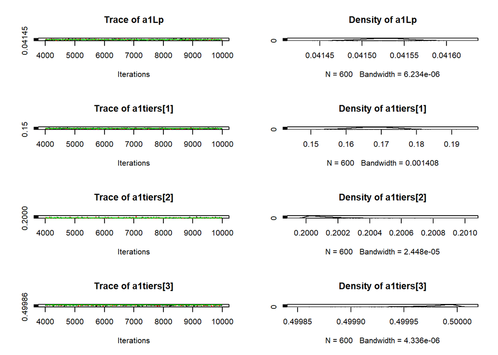

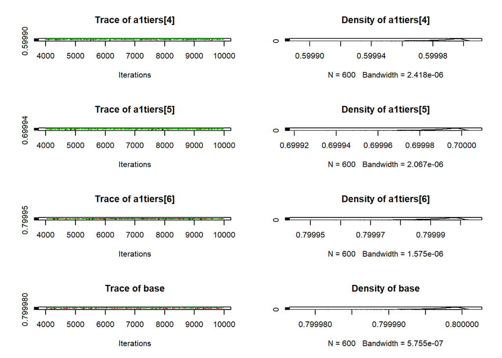

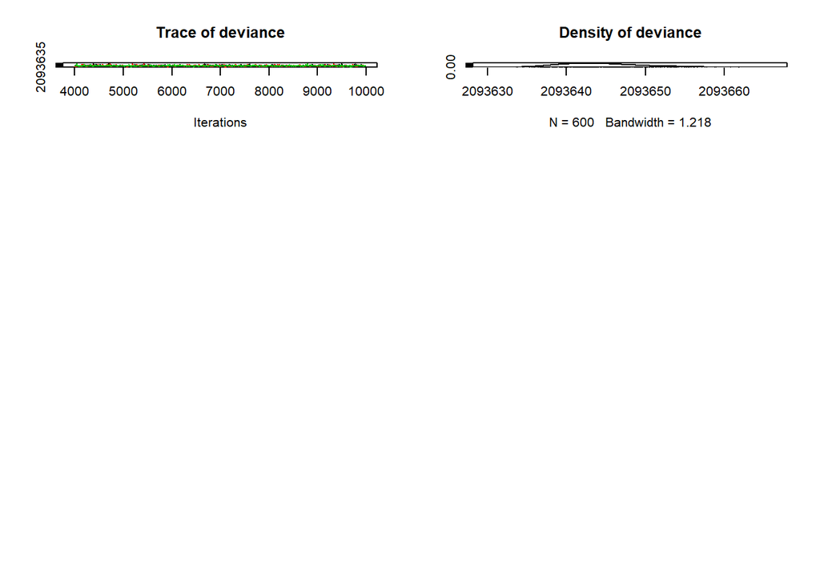

```r
#here we will see the trace plots on the chanins and their density
mcmc_lm <- as.mcmc(mod1.fit)
plot(mcmc_lm)
```

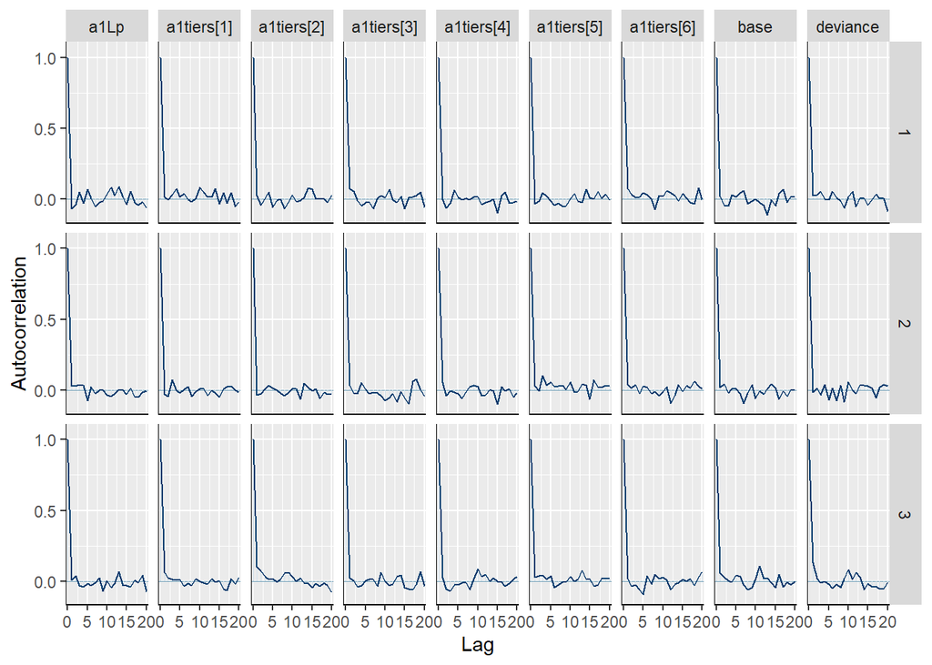

```r
#now we want to see how the autocorrelation is in our #model, since is hard to develop #models with good n.eff
chains <- mod1.fit$BUGSoutput$sims.array
bayesplot::mcmc_acf(chains)
```

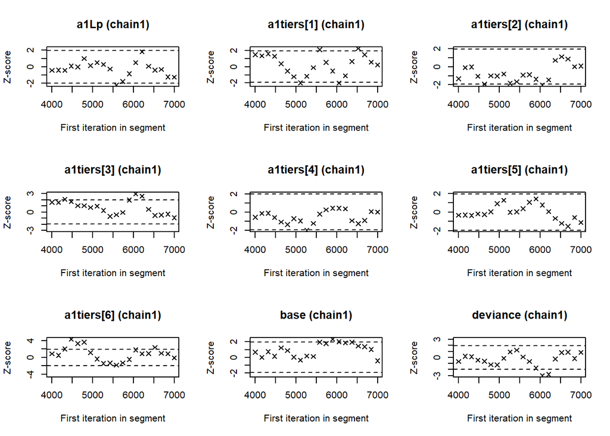

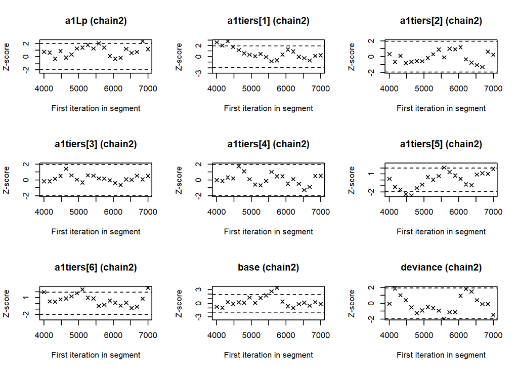

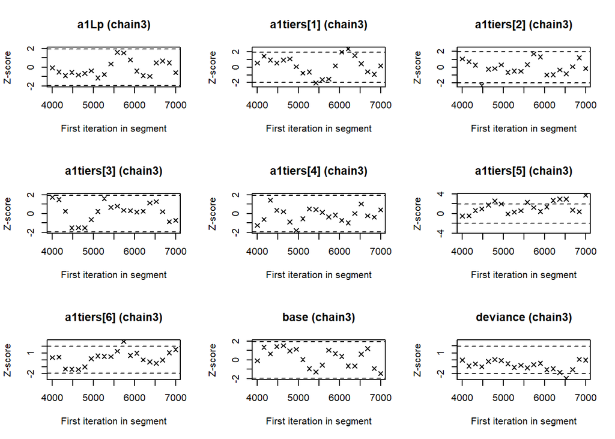

```r
# Diagnostic with coda
coda.fit <- as.mcmc(mod1.fit)

coda::geweke.plot(coda.fit)
```

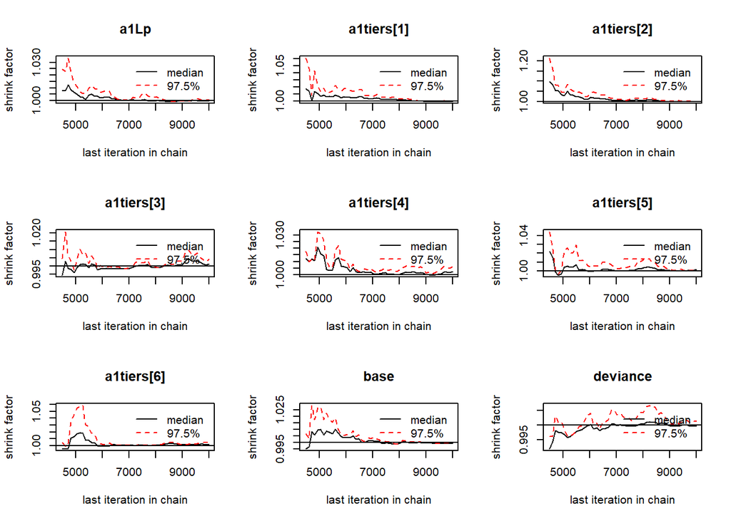

```r
coda::gelman.plot(coda.fit)
```

```r
#we now manipulate the chain
chainMat <- mod1.fit$BUGSoutput$sims.matrix

' Point estimates'
```

```
## [1] " Point estimates"
```

```r
(Exp.hat.jags <- colMeans(chainMat))
```

```
##         a1Lp   a1tiers[1]   a1tiers[2]   a1tiers[3]   a1tiers[4]   a1tiers[5]
## 4.152632e-02 1.679936e-01 2.001243e-01 4.999781e-01 5.999875e-01 6.999898e-01
##   a1tiers[6]         base     deviance
## 7.999923e-01 7.999971e-01 2.093645e+06
```

```r
'---------------------------'
```

```
## [1] "---------------------------"
```

```r
' Intervals ET'
```

```
## [1] " Intervals ET"
```

```r
cred <- 0.95
(Exp.ET.jags <- apply(chainMat, 2, quantile, prob=c((1-cred)/2, 1-(1-cred)/2)))
```

```
##             a1Lp a1tiers[1] a1tiers[2] a1tiers[3] a1tiers[4] a1tiers[5]
## 2.5%  0.04147398  0.1560129  0.2000028  0.4999202  0.5999540  0.6999625
## 97.5% 0.04157736  0.1792824  0.2004744  0.4999994  0.5999997  0.6999997
##       a1tiers[6]      base deviance
## 2.5%   0.7999717 0.7999894  2093636
## 97.5%  0.7999998 0.7999999  2093656
```

```r
#beta.ET.jags
'-----------------------'
```

```
## [1] "-----------------------"
```

```r
'HPD'
```

```
## [1] "HPD"
```

```r
# What about the HPD?
(Exp.HPD.jags <- coda::HPDinterval(as.mcmc(chainMat)))
```

```
##                   lower        upper
## a1Lp       4.147389e-02 4.157736e-02
## a1tiers[1] 1.566550e-01 1.797601e-01
## a1tiers[2] 2.000000e-01 2.003766e-01
## a1tiers[3] 4.999337e-01 5.000000e-01
## a1tiers[4] 5.999619e-01 6.000000e-01
## a1tiers[5] 6.999700e-01 7.000000e-01
## a1tiers[6] 7.999775e-01 8.000000e-01
## base       7.999913e-01 8.000000e-01
## deviance   2.093636e+06 2.093655e+06
## attr(,"Probability")
## [1] 0.95
```

```r
#they seem to agree with the point estimate and we see that the HDP seems smaller and #probably more precise
```